```python
from fastai.collab import *
from fastai.tabular.all import *
from time import *
```

# Daily weather in Antwerp, Belgium from 2011 to 2021

Weather data was bought from OpenWeather. The document that explains the content of the .csv file can be found here: https://openweathermap.org/history-bulk

```python
path = Path('.')
weather = pd.read_csv(path/'OpenWeather_Antwerp.csv', delimiter=',', engine='python', header=0)
len(weather)
```

```
81766
```

```python
weather.head()
```

|  | dt | dt_iso | timezone | city_name | lat | lon | temp | temp_min | temp_max | pressure | ... | wind_deg | rain_1h | rain_3h | snow_1h | snow_3h | clouds_all | weather_id | weather_main | weather_description | weather_icon |
| --- | --- | --- | --- | --- | --- | --- | --- | --- | --- | --- | --- | --- | --- | --- | --- | --- | --- | --- | --- | --- | --- |
| 0 | 1317427200 | 2011-10-01 00:00:00 +0000 UTC | 7200 | Antwerp | 51.219448 | 4.402464 | 13.05 | 12.3 | 14.00 | 1025 | ... | 162 | NaN | NaN | NaN | NaN | 1 | 800 | Clear | sky is clear | 01n |
| 1 | 1317430800 | 2011-10-01 01:00:00 +0000 UTC | 7200 | Antwerp | 51.219448 | 4.402464 | 12.89 | 12.0 | 14.50 | 1025 | ... | 171 | NaN | NaN | NaN | NaN | 1 | 800 | Clear | sky is clear | 01n |
| 2 | 1317434400 | 2011-10-01 02:00:00 +0000 UTC | 7200 | Antwerp | 51.219448 | 4.402464 | 12.22 | 11.5 | 13.34 | 1025 | ... | 90 | NaN | NaN | NaN | NaN | 1 | 800 | Clear | sky is clear | 01n |
| 3 | 1317438000 | 2011-10-01 03:00:00 +0000 UTC | 7200 | Antwerp | 51.219448 | 4.402464 | 11.85 | 11.0 | 13.76 | 1025 | ... | 175 | NaN | NaN | NaN | NaN | 1 | 800 | Clear | sky is clear | 01n |
| 4 | 1317441600 | 2011-10-01 04:00:00 +0000 UTC | 7200 | Antwerp | 51.219448 | 4.402464 | 11.02 | 10.2 | 13.18 | 1025 | ... | 130 | NaN | NaN | NaN | NaN | 20 | 801 | Clouds | few clouds | 02n |

5 rows × 24 columns

```python
weather.isna().sum()
```

```
dt                         0
dt_iso                     0
timezone                   0
city_name                  0
lat                        0
lon                        0
temp                       0
temp_min                   0
temp_max                   0
pressure                   0
sea_level              81766
grnd_level             81766
humidity                   0
wind_speed                 0
wind_deg                   0
rain_1h                72615
rain_3h                81766
snow_1h                81601
snow_3h                81766
clouds_all                 0
weather_id                 0
weather_main               0
weather_description        0
weather_icon               0
dtype: int64
```

As the summary above, there are some columns that contain (mostly) only null data. In addition, there are some columns that do not have nay contribution to the prediction such as weather_description, weather_main, icon, etc. Therefore, the first step is to remove all useless, redundant columns from the data frame.

```python
to_remove = ['dt','timezone','city_name','lat','lon','pressure','sea_level','grnd_level','rain_1h','rain_3h','snow_1h','snow_3h','weather_main','weather_description','weather_icon', 'temp_min', 'temp_max']
weather.drop(to_remove, axis=1, inplace=True)
```

```python
weather.head()
```

|  | dt_iso | temp | humidity | wind_speed | wind_deg | clouds_all | weather_id |
| --- | --- | --- | --- | --- | --- | --- | --- |
| 0 | 2011-10-01 00:00:00 +0000 UTC | 13.05 | 91 | 2.58 | 162 | 1 | 800 |
| 1 | 2011-10-01 01:00:00 +0000 UTC | 12.89 | 91 | 2.47 | 171 | 1 | 800 |
| 2 | 2011-10-01 02:00:00 +0000 UTC | 12.22 | 96 | 1.00 | 90 | 1 | 800 |
| 3 | 2011-10-01 03:00:00 +0000 UTC | 11.85 | 91 | 1.86 | 175 | 1 | 800 |
| 4 | 2011-10-01 04:00:00 +0000 UTC | 11.02 | 96 | 1.00 | 130 | 20 | 801 |

As shown in the table above, data were collected also during the night. These stats do not have any meaning since there is no sun, thus no energy generated at night. Futhermore, having them in the training dataset can significantly reduce the quality of the model. Assuming that there is completely no sun between 22:00 and 04:00 of the next day, rows whose 'clock' belongs to this time interval are removed:

```python
for i in range(len(weather)):
    if int(weather['dt_iso'][i][11:13]) < 4 or int(weather['dt_iso'][i][11:13]) > 22:
        weather.drop(index=i, axis=0, inplace=True)
```

After removing night time data, the number of rows left in the table is:

```python
len(weather)
```

```
64822
```

```python
weather.reset_index(inplace=True)
weather.head()
```

|  | index | dt_iso | temp | humidity | wind_speed | wind_deg | clouds_all | weather_id |
| --- | --- | --- | --- | --- | --- | --- | --- | --- |
| 0 | 4 | 2011-10-01 04:00:00 +0000 UTC | 11.02 | 96 | 1.00 | 130 | 20 | 801 |
| 1 | 5 | 2011-10-01 05:00:00 +0000 UTC | 11.44 | 90 | 1.47 | 157 | 1 | 741 |
| 2 | 6 | 2011-10-01 06:00:00 +0000 UTC | 10.56 | 97 | 1.00 | 110 | 1 | 741 |
| 3 | 7 | 2011-10-01 07:00:00 +0000 UTC | 12.45 | 93 | 1.00 | 90 | 1 | 800 |
| 4 | 8 | 2011-10-01 08:00:00 +0000 UTC | 17.03 | 96 | 0.59 | 146 | 20 | 801 |

The solar energy production data published by Frank (https://www.kaggle.com/fvcoppen/solarpanelspower) contains only daily data. Therefore data in the dataframe above which were collected in the same day need to be gather together into a single rows. There are two options to do this: 1) Make columns of every hour in a day and 2) Calculate the value for morning, noon and afternoon.

The choice should be made based on the weather forecast given by OpenWeather. There are two types of data: 1) One Call API that gives hourly forecast for 48 hours and 2) 5 Day / 3 Hour forecast, where The API response is the forecast of 3 hours for the next 5 days.

For now, the second option is used to predict the solar energy 5 day ahead. The data will be averaged out whithin 3 time frames: 04:00 to 11:00, 11:00 to 16:00, and 16:00 to 22:00. Note that weather_id is categorical data, it will not be averaged but the most popular data will be taken instead.

```python
#To find the value with the most apperance
from collections import Counter

def most_frequent(lst):
    data = Counter(lst)
    return data.most_common(1)[0][0]
```

```python
def simplify_data(weather):
    new_data = pd.DataFrame(columns = ['date',
                                       'mor_temp','mor_humid','mor_wspd','mor_wdeg','mor_cloud','mor_weather_id',
                                       'noo_temp','noo_humid','noo_wspd','noo_wdeg','noo_cloud','noo_weather_id',
                                       'aft_temp','aft_humid','aft_wspd','aft_wdeg','aft_cloud','aft_weather_id',])

    mor_count, mor_temp, mor_humid, mor_wspd, mor_wdeg, mor_cloud = [0]*6
    noo_count, noo_temp, noo_humid, noo_wspd, noo_wdeg, noo_cloud = [0]*6
    aft_count, aft_temp, aft_humid, aft_wspd, aft_wdeg, aft_cloud = [0]*6

    mor_weather_id=[]
    noo_weather_id=[]
    aft_weather_id=[]

    current_date = weather.loc[0, 'dt_iso'][0:10]

    for i in range(len(weather)):
        if weather.loc[i, 'dt_iso'][0:10] != current_date:
            new_data = new_data.append({
                'date':current_date,
                'mor_temp':mor_temp/mor_count,
                'mor_humid':mor_humid/mor_count,
                'mor_wspd':mor_wspd/mor_count,
                'mor_wdeg':mor_wdeg/mor_count,
                'mor_cloud':mor_cloud/mor_count,
                'mor_weather_id':most_frequent(mor_weather_id),
                'noo_temp':noo_temp/noo_count,
                'noo_humid':noo_humid/noo_count,
                'noo_wspd':noo_wspd/noo_count,
                'noo_wdeg':noo_wdeg/noo_count,
                'noo_cloud':noo_cloud/noo_count,
                'noo_weather_id':most_frequent(noo_weather_id),
                'aft_temp':aft_temp/aft_count,
                'aft_humid':aft_humid/aft_count,
                'aft_wspd':aft_wspd/aft_count,
                'aft_wdeg':aft_wdeg/aft_count,
                'aft_cloud':aft_cloud/aft_count,
                'aft_weather_id':most_frequent(aft_weather_id)
            }, ignore_index=True)

            mor_count, mor_temp, mor_humid, mor_wspd, mor_wdeg, mor_cloud = [0]*6
            noo_count, noo_temp, noo_humid, noo_wspd, noo_wdeg, noo_cloud = [0]*6
            aft_count, aft_temp, aft_humid, aft_wspd, aft_wdeg, aft_cloud = [0]*6

            mor_weather_id=[]
            noo_weather_id=[]
            aft_weather_id=[]

            current_date = weather.loc[i, 'dt_iso'][0:10]

        if int(weather.loc[i, 'dt_iso'][11:13]) < 11:
            mor_count += 1
            mor_temp += weather.loc[i, 'temp']
            mor_humid += weather.loc[i, 'humidity']
            mor_wspd += weather.loc[i, 'wind_speed']
            mor_wdeg += weather.loc[i, 'wind_deg']
            mor_cloud += weather.loc[i, 'clouds_all']
            mor_weather_id.append(weather['weather_id'][i])

        elif int(weather.loc[i, 'dt_iso'][11:13]) < 16:
            noo_count += 1
            noo_temp += weather.loc[i, 'temp']
            noo_humid += weather.loc[i, 'humidity']
            noo_wspd += weather.loc[i, 'wind_speed']
            noo_wdeg += weather.loc[i, 'wind_deg']
            noo_cloud += weather.loc[i, 'clouds_all']
            noo_weather_id.append(weather['weather_id'][i])

        else:
            aft_count += 1
            aft_temp += weather.loc[i, 'temp']
            aft_humid += weather.loc[i, 'humidity']
            aft_wspd += weather.loc[i, 'wind_speed']
            aft_wdeg += weather.loc[i, 'wind_deg']
            aft_cloud += weather.loc[i, 'clouds_all']
            aft_weather_id.append(weather['weather_id'][i])

    return new_data
```

```python
weather_new = simplify_data(weather)
```

```python
weather_new.info()
```

```
<class 'pandas.core.frame.DataFrame'>
RangeIndex: 3380 entries, 0 to 3379
Data columns (total 19 columns):
 #   Column          Non-Null Count  Dtype
---  ------          --------------  -----
 0   date            3380 non-null   object
 1   mor_temp        3380 non-null   float64
 2   mor_humid       3380 non-null   float64
 3   mor_wspd        3380 non-null   float64
 4   mor_wdeg        3380 non-null   float64
 5   mor_cloud       3380 non-null   float64
 6   mor_weather_id  3380 non-null   object
 7   noo_temp        3380 non-null   float64
 8   noo_humid       3380 non-null   float64
 9   noo_wspd        3380 non-null   float64
 10  noo_wdeg        3380 non-null   float64
 11  noo_cloud       3380 non-null   float64
 12  noo_weather_id  3380 non-null   object
 13  aft_temp        3380 non-null   float64
 14  aft_humid       3380 non-null   float64
 15  aft_wspd        3380 non-null   float64
 16  aft_wdeg        3380 non-null   float64
 17  aft_cloud       3380 non-null   float64
 18  aft_weather_id  3380 non-null   object
dtypes: float64(15), object(4)
memory usage: 501.8+ KB
```

```python
weather_new.head()
```

|  | date | mor_temp | mor_humid | mor_wspd | mor_wdeg | mor_cloud | mor_weather_id | noo_temp | noo_humid | noo_wspd | noo_wdeg | noo_cloud | noo_weather_id | aft_temp | aft_humid | aft_wspd | aft_wdeg | aft_cloud | aft_weather_id |
| --- | --- | --- | --- | --- | --- | --- | --- | --- | --- | --- | --- | --- | --- | --- | --- | --- | --- | --- | --- |
| 0 | 2011-10-01 | 15.060000 | 88.714286 | 1.151429 | 120.428571 | 6.428571 | 800 | 25.066 | 54.0 | 2.0 | 112.0 | 1.0 | 800 | 18.624286 | 77.428571 | 1.574286 | 87.571429 | 0.428571 | 800 |
| 1 | 2011-10-02 | 14.707143 | 87.142857 | 1.000000 | 114.285714 | 3.714286 | 800 | 24.984 | 48.6 | 1.2 | 156.0 | 1.0 | 800 | 17.904286 | 71.571429 | 1.272857 | 187.142857 | 1.000000 | 800 |
| 2 | 2011-10-03 | 15.977143 | 72.285714 | 2.428571 | 200.000000 | 9.714286 | 800 | 24.630 | 46.4 | 4.0 | 232.0 | 22.0 | 801 | 20.904286 | 57.714286 | 2.857143 | 208.571429 | 0.285714 | 800 |
| 3 | 2011-10-04 | 16.457143 | 85.428571 | 3.857143 | 232.857143 | 72.142857 | 803 | 18.470 | 72.4 | 5.6 | 262.0 | 53.0 | 803 | 17.328571 | 73.857143 | 4.428571 | 245.714286 | 72.142857 | 803 |
| 4 | 2011-10-05 | 16.691429 | 84.571429 | 4.714286 | 234.285714 | 72.142857 | 803 | 18.416 | 72.4 | 6.4 | 232.0 | 40.0 | 802 | 17.367143 | 73.000000 | 6.000000 | 232.857143 | 55.000000 | 802 |

The original data ends up with 3380 rows of daily data. At this moment, the weather dataset is already at its finest form. In following steps, the energy data will be processed.

# Daily solar power production in Antwerp dataset

The dataset is provided by Frank, a Kaggle user (https://www.kaggle.com/fvcoppen/solarpanelspower).

```python
energy = pd.read_csv(path/'PV_Elec_Gas3.csv', delimiter=',', engine='python', header=0)
```

```python
energy.head()
```

|  | date | Cumulative_solar_power | kWh electricity/day | Gas/day |
| --- | --- | --- | --- | --- |
| 0 | 26/10/2011 | 0.1 | 15.1 | 9.0 |
| 1 | 27/10/2011 | 10.2 | 7.4 | 9.2 |
| 2 | 28/10/2011 | 20.2 | 5.8 | 8.0 |
| 3 | 29/10/2011 | 29.6 | 4.9 | 6.6 |
| 4 | 30/10/2011 | 34.2 | 11.7 | 5.3 |

```python
energy.info()
```

```
<class 'pandas.core.frame.DataFrame'>
RangeIndex: 3304 entries, 0 to 3303
Data columns (total 4 columns):
 #   Column                  Non-Null Count  Dtype
---  ------                  --------------  -----
 0   date                    3304 non-null   object
 1   Cumulative_solar_power  3304 non-null   float64
 2   kWh electricity/day     3304 non-null   float64
 3   Gas/day                 3304 non-null   float64
dtypes: float64(3), object(1)
memory usage: 103.4+ KB
```

Two datasets will be merged using the 'date' column. Therefore, data data of the energy production table and the weather table must be casted to datetime64

```python
#energy table
energy.date = pd.to_datetime(energy.date)
energy.set_index(['date'], inplace=True)       #change the index
#weather table
weather_new.date = pd.to_datetime(weather_new.date)
weather_new.set_index(['date'], inplace=True)       #change the index
```

```python
weather_new.head()
```

| date | mor_temp | mor_humid | mor_wspd | mor_wdeg | mor_cloud | mor_weather_id | noo_temp | noo_humid | noo_wspd | noo_wdeg | noo_cloud | noo_weather_id | aft_temp | aft_humid | aft_wspd | aft_wdeg | aft_cloud | aft_weather_id |
| --- | --- | --- | --- | --- | --- | --- | --- | --- | --- | --- | --- | --- | --- | --- | --- | --- | --- | --- |
| 2011-10-01 | 15.060000 | 88.714286 | 1.151429 | 120.428571 | 6.428571 | 800 | 25.066 | 54.0 | 2.0 | 112.0 | 1.0 | 800 | 18.624286 | 77.428571 | 1.574286 | 87.571429 | 0.428571 | 800 |
| 2011-10-02 | 14.707143 | 87.142857 | 1.000000 | 114.285714 | 3.714286 | 800 | 24.984 | 48.6 | 1.2 | 156.0 | 1.0 | 800 | 17.904286 | 71.571429 | 1.272857 | 187.142857 | 1.000000 | 800 |
| 2011-10-03 | 15.977143 | 72.285714 | 2.428571 | 200.000000 | 9.714286 | 800 | 24.630 | 46.4 | 4.0 | 232.0 | 22.0 | 801 | 20.904286 | 57.714286 | 2.857143 | 208.571429 | 0.285714 | 800 |
| 2011-10-04 | 16.457143 | 85.428571 | 3.857143 | 232.857143 | 72.142857 | 803 | 18.470 | 72.4 | 5.6 | 262.0 | 53.0 | 803 | 17.328571 | 73.857143 | 4.428571 | 245.714286 | 72.142857 | 803 |
| 2011-10-05 | 16.691429 | 84.571429 | 4.714286 | 234.285714 | 72.142857 | 803 | 18.416 | 72.4 | 6.4 | 232.0 | 40.0 | 802 | 17.367143 | 73.000000 | 6.000000 | 232.857143 | 55.000000 | 802 |

```python
energy.head()
```

| date | Cumulative_solar_power | kWh electricity/day | Gas/day |
| --- | --- | --- | --- |
| 2011-10-26 | 0.1 | 15.1 | 9.0 |
| 2011-10-27 | 10.2 | 7.4 | 9.2 |
| 2011-10-28 | 20.2 | 5.8 | 8.0 |
| 2011-10-29 | 29.6 | 4.9 | 6.6 |
| 2011-10-30 | 34.2 | 11.7 | 5.3 |

The solar power production is the only thing that matter, hence the other two should be removed.

```python
energy.drop(labels='kWh electricity/day', axis=1, inplace=True)
energy.drop(labels='Gas/day', axis=1, inplace=True)
energy.rename(columns = {'Cumulative_solar_power':'cum_power'}, inplace = True)
energy.head()
```

| date | cum_power |
| --- | --- |
| 2011-10-26 | 0.1 |
| 2011-10-27 | 10.2 |
| 2011-10-28 | 20.2 |
| 2011-10-29 | 29.6 |
| 2011-10-30 | 34.2 |

According to the description of the dataset, data were recorded at the beginning of days. Therfore, the info in the table actually describes the cum_power in the previous day. Since the purpose of this project is to find out the relationship between weather and daily energy production, the daily number also needs to be calculated from accumulate data.

```python
energy = energy.shift(periods=-1, freq='D', axis=0) #step one day back

power_list = [0] * len(energy)
power_list[0] = energy['cum_power'][0]

for i in range(len(energy)-1):
    power_list[i+1] = energy['cum_power'][i+1] - energy['cum_power'][i]

energy.insert(1, "daily_power", power_list, True)
energy.drop(labels='cum_power', axis=1, inplace=True)
```

```python
energy.head()
```

| date | daily_power |
| --- | --- |
| 2011-10-25 | 0.1 |
| 2011-10-26 | 10.1 |
| 2011-10-27 | 10.0 |
| 2011-10-28 | 9.4 |
| 2011-10-29 | 4.6 |

The data in the first row is not correct, it must be discarded.

```python
energy = energy.iloc[1:]
```

```python
energy.head()
```

| date | daily_power |
| --- | --- |
| 2011-10-26 | 10.1 |
| 2011-10-27 | 10.0 |
| 2011-10-28 | 9.4 |
| 2011-10-29 | 4.6 |
| 2011-10-30 | 3.8 |

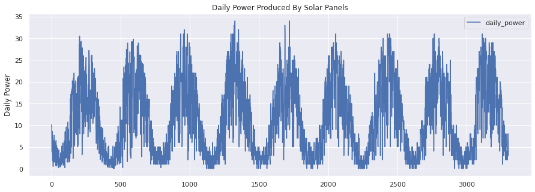

```python
import seaborn as sns

sns.set()
power_index= energy.reset_index()

power_index.plot(y='daily_power', figsize=(15,5))

plt.title('Daily Power Produced By Solar Panels')
plt.ylabel('Daily Power')
plt.show()
```

This is interesting. Because it show how the energy production varies during years. The recorded data reaches its peak during the summer and drop to bottom in the winter.

```python
def merge_weatherANDpower():
    dataset = weather_new.merge(energy, on=['date'])
    return dataset

final_dataset = merge_weatherANDpower()
final_dataset.head()
```

| date | mor_temp | mor_humid | mor_wspd | mor_wdeg | mor_cloud | mor_weather_id | noo_temp | noo_humid | noo_wspd | noo_wdeg | noo_cloud | noo_weather_id | aft_temp | aft_humid | aft_wspd | aft_wdeg | aft_cloud | aft_weather_id | daily_power |
| --- | --- | --- | --- | --- | --- | --- | --- | --- | --- | --- | --- | --- | --- | --- | --- | --- | --- | --- | --- |
| 2011-10-10 | 16.798571 | 82.285714 | 7.285714 | 250.000000 | 62.142857 | 803 | 18.784 | 69.6 | 7.60 | 244.0 | 32.0 | 802 | 16.752857 | 77.857143 | 7.000000 | 250.000000 | 45.000000 | 802 | 6.4 |
| 2011-10-11 | 15.838571 | 81.428571 | 7.142857 | 245.714286 | 62.142857 | 802 | 17.404 | 74.4 | 6.40 | 252.0 | 75.0 | 803 | 16.172857 | 79.000000 | 6.100000 | 247.142857 | 67.142857 | 803 | 4.8 |
| 2011-10-26 | 10.331429 | 83.000000 | 4.857143 | 194.285714 | 77.142857 | 803 | 13.438 | 63.4 | 5.80 | 186.0 | 51.0 | 803 | 10.824286 | 74.857143 | 2.428571 | 148.571429 | 9.000000 | 800 | 10.1 |
| 2011-10-27 | 9.051429 | 80.285714 | 3.428571 | 111.428571 | 56.571429 | 803 | 16.068 | 58.2 | 5.60 | 142.0 | 75.0 | 803 | 12.577143 | 77.285714 | 2.142857 | 131.428571 | 67.142857 | 803 | 10.0 |
| 2011-10-28 | 11.831429 | 84.857143 | 1.428571 | 177.142857 | 49.571429 | 801 | 17.372 | 67.4 | 1.29 | 194.6 | 17.0 | 801 | 13.801429 | 81.714286 | 1.198571 | 132.857143 | 44.285714 | 802 | 9.4 |

```python
len(final_dataset)
```

```
3285
```

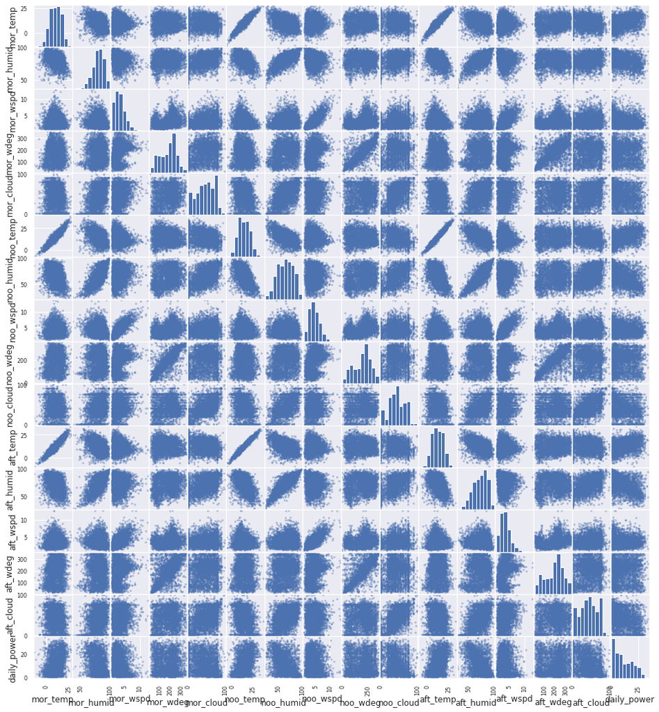

```python
from pandas.plotting import scatter_matrix
scatter_matrix(final_dataset, figsize=(16,18), alpha=0.4)
plt.show()
```

[output not shown]

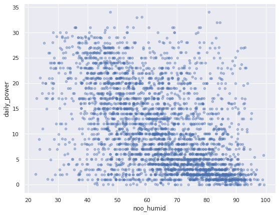

```python
#To delete data anomalies
import random
final_dataset.daily_power = final_dataset.daily_power.apply(lambda x: x+random.randint(0,5)/100 if x==0 else x)
for i in range(1,35):
    final_dataset.daily_power = final_dataset.daily_power.apply(lambda x: x+random.randint(-5,5)/100 if x==i else x)
final_dataset.plot(kind='scatter', x= 'noo_humid',y='daily_power', figsize=(9,7), alpha=0.4)
plt.show()
```

```python
final_dataset.to_csv('training_data_v3_1.csv')
```